# Machine Learning Course Project

## Analysis Methodology

### 1. Loading data

The data for this project comes from http://groupware.les.inf.puc-rio.br/har. The training data is downloaded from https://d396qusza40orc.cloudfront.net/predmachlearn/pml-training.csv, and the test data is downloaded from https://d396qusza40orc.cloudfront.net/predmachlearn/pml-testing.csv

```r
# Loading data
train <- read.csv("D:/CAREER/DS Course/ML/pml-training.csv", na.strings=c("NA","#DIV/0!", ""))
test <- read.csv("D:/CAREER/DS Course/ML/pml-testing.csv", na.strings=c("NA","#DIV/0!", ""))
# view data structure
str(train)
unique(train$classe)
```

[output not shown]

The outcome variable “classe”" has five values: 1. Class A - exactly according to the specification; 2. Class B - throwing the elbows to the front; 3. Class C - lifting the dumbbell only halfway; 4. Class D - lowering the dumbbell only halfway; 5. Class E - throwing the hips to the front. There are too many variables in the data set and not every variable is related to the outcome, so data needs to be cleaned before building the model.

### 2. Cross-validation

To perform cross-validation, the traninig data set is split into two subsets: TrainT, which is 70% of the original Training data set,is used for model fitting; the rest of the 30% is for model testing. After we choose the better model, the original Testing data set will be used for forcasting.

```r
# load libraries
library(caret)
library(lattice)
library(ggplot2)
library(randomForest)
library(rpart)
library(rpart.plot)
library(RColorBrewer)
library(rattle)

# split data
set.seed(1234)
TrainTrain <- createDataPartition(y=train$classe,p=.70,list=F)
TrainT <- train[TrainTrain,]
TestT <- train[-TrainTrain,]
```

AS not every variable in the Tranining data is suitable for prediction,non-predictors such as identifier, timestamp, and window data are exlcuded. Also, variables with too many NA values are revmoved. After clearning up, 52 variables could be used for prediction.

```r
#exclude  (they cannot be used for prediction)
TrainTC <- TrainT[,-grep("name|timestamp|window|X", colnames(TrainT), value=F)]
#take out variables with over 80% of  missing data
TrainTC[TrainTC==""] <- NA
TrainTC <- TrainTC[!(apply(TrainTC, 2, function(x) sum(is.na(x)))/nrow(TrainTC)>0.80)]
dim(TrainTC)
```

[output not shown]

### Model 1: Decision Tree

Decision Tree is performed to predict classes using the 52 variables in the TrainTC data set.

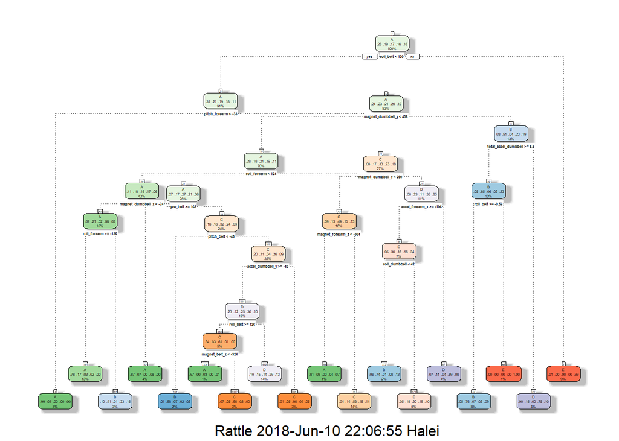

```r
# Decision Tree modeling
DT <- rpart(classe ~ ., data=TrainTC, method="class")
# Decision Tree plot
fancyRpartPlot(DT)
```

Predicting on the test data and generate model parameters

```r
# predicting
DTpredict <- predict(DT, TestT, type = "class")
# display results of the prediction
confusionMatrix(DTpredict, TestT$classe)
```

```
## Confusion Matrix and Statistics
##
##           Reference
## Prediction    A    B    C    D    E
##          A 1364  169   24   48   16
##          B   60  581   46   79   74
##          C   52  137  765  129  145
##          D  183  194  125  650  159
##          E   15   58   66   58  688
##
## Overall Statistics
##
##                Accuracy : 0.6879
##                  95% CI : (0.6758, 0.6997)
##     No Information Rate : 0.2845
##     P-Value [Acc > NIR] : < 2.2e-16
##
##                   Kappa : 0.6066
##  Mcnemar's Test P-Value : < 2.2e-16
##
## Statistics by Class:
##
##                      Class: A Class: B Class: C Class: D Class: E
## Sensitivity            0.8148  0.51010   0.7456   0.6743   0.6359
## Specificity            0.9390  0.94543   0.9047   0.8657   0.9590
## Pos Pred Value         0.8415  0.69167   0.6230   0.4958   0.7774
## Neg Pred Value         0.9273  0.88940   0.9440   0.9314   0.9212
## Prevalence             0.2845  0.19354   0.1743   0.1638   0.1839
## Detection Rate         0.2318  0.09873   0.1300   0.1105   0.1169
## Detection Prevalence   0.2754  0.14274   0.2087   0.2228   0.1504
## Balanced Accuracy      0.8769  0.72776   0.8252   0.7700   0.7974
```

Decision Tree model has an accuracy of 0.6879, with 95% CI of (0.6758, 0.6997), which translates to an out of sample error of 0.3121.

### Model 2: Random Forest

```r
RF <- randomForest(classe ~. , data=TrainTC)
RFPredict <- predict(RF, TestT, type = "class")
confusionMatrix(RFPredict, TestT$classe)
```

```
## Confusion Matrix and Statistics
##
##           Reference
## Prediction    A    B    C    D    E
##          A 1674    7    0    0    0
##          B    0 1131    6    0    0
##          C    0    1 1020    4    1
##          D    0    0    0  959    1
##          E    0    0    0    1 1080
##
## Overall Statistics
##
##                Accuracy : 0.9964
##                  95% CI : (0.9946, 0.9978)
##     No Information Rate : 0.2845
##     P-Value [Acc > NIR] : < 2.2e-16
##
##                   Kappa : 0.9955
##  Mcnemar's Test P-Value : NA
##
## Statistics by Class:
##
##                      Class: A Class: B Class: C Class: D Class: E
## Sensitivity            1.0000   0.9930   0.9942   0.9948   0.9982
## Specificity            0.9983   0.9987   0.9988   0.9998   0.9998
## Pos Pred Value         0.9958   0.9947   0.9942   0.9990   0.9991
## Neg Pred Value         1.0000   0.9983   0.9988   0.9990   0.9996
## Prevalence             0.2845   0.1935   0.1743   0.1638   0.1839
## Detection Rate         0.2845   0.1922   0.1733   0.1630   0.1835
## Detection Prevalence   0.2856   0.1932   0.1743   0.1631   0.1837
## Balanced Accuracy      0.9992   0.9959   0.9965   0.9973   0.9990
```

## Model Selection and Prediction

```r
predictFinal <- predict(RF, test, type = "class")
predictFinal
```

```
##  1  2  3  4  5  6  7  8  9 10 11 12 13 14 15 16 17 18 19 20
##  B  A  B  A  A  E  D  B  A  A  B  C  B  A  E  E  A  B  B  B
## Levels: A B C D E
```